# Workshop 1: Mapping Philippine Cities

- Show All Code
- Hide All Code
- View Source

Land Rent Gradients and Urban Productivity in Metro Manila

Author

Jem Marie Nario

## Overview

This workshop introduces **spatial data analysis in R** using real Philippine Statistical Authority (PSA) data. By the end of this session, you will be able to:

1. Load and inspect a city-level spatial dataset for Metro Manila (NCR)
2. Join tabular data to shapefiles using `sf`
3. Produce choropleth maps with `ggplot2`
4. Visualize the **land rent gradient** — how rent declines with distance from the central business district (CBD)
5. Map **human capital indicators** as proxies for urban productivity

**Note**

**Data sources**  
- **FIES 2023** (Family Income and Expenditure Survey) — PSA  
- **CPH 2020** (Census of Population and Housing, Form 2) — PSA  
- Both datasets are aggregated to the city/municipality level (n = 17 NCR LGUs)

## 1 · Setup

### 1.1 Install and load packages

```r
# Install if needed (run once)
# install.packages(c("sf", "ggplot2", "dplyr", "ggrepel",
#                    "scales", "viridis", "patchwork", "geodata"))

library(tidyverse)
library(sf)          # spatial data structures
library(geodata)     # get spatial data polygons
library(ggplot2)     # grammar of graphics
library(ggrepel)     # non-overlapping labels
library(dplyr)       # data wrangling
library(scales)      # axis formatting
library(viridis)     # colour scales
library(patchwork)   # combine plots
```

### 1.2 Load the training dataset

```r
# Load the pre-assembled NCR city dataset
# Contains FIES 2023 + CPH 2020 variables at city level
load("data/ncr_city_training.RData")   # loads as 'ncr_city'

# Quick look
glimpse(ncr_city)
```

```
Rows: 17
Columns: 22
$ city               <chr> "Makati", "Mandaluyong", "Pasay", "Taguig", "Patero…
$ lat                <dbl> 14.5547, 14.5794, 14.5378, 14.5243, 14.5458, 14.601…
$ lon                <dbl> 121.0244, 121.0284, 121.0027, 121.0568, 121.0686, 1…
$ dist_cbd_km        <dbl> 0.000000, 2.780046, 2.997720, 4.856761, 4.859033, 5…
$ mean_rentval       <dbl> 159465.79, 106003.42, 66199.26, 69318.26, 68223.88,…
$ mean_actrent       <dbl> 44144.873, 30605.830, 24827.624, 18703.939, 15764.9…
$ mean_inc           <dbl> 799536.3, 666018.8, 477314.3, 519597.5, 504768.3, 8…
$ mean_wage_inc      <dbl> 481502.3, 423220.0, 329859.2, 342724.3, 328892.3, 4…
$ mean_educ_exp      <dbl> 11132.353, 14902.124, 7870.102, 10000.592, 9574.199…
$ rent_inc_ratio     <dbl> 0.1993812, 0.1691527, 0.1517436, 0.1464884, 0.15101…
$ wage_inc_share     <dbl> 0.6361797, 0.6281935, 0.6738297, 0.6515455, 0.62627…
$ pct_renters_fies   <dbl> 38.66113, 34.53750, 46.81573, 35.81175, 30.47378, 4…
$ n_hh               <int> 246670, 144781, 176224, 252183, 16734, 36515, 55837…
$ pct_renter         <dbl> 0.7921515, 1.8952763, 1.1666969, 0.4817930, 0.32269…
$ pct_any_rent       <dbl> 23.76819, 29.05285, 32.71064, 35.77124, 26.78379, 3…
$ pct_makeshift_wall <dbl> 0.1078364, 0.0849559, 0.1963410, 0.2466463, 0.21513…
$ pct_strong_wall    <dbl> 90.66972, 79.71764, 81.37995, 86.97454, 79.60440, 7…
$ pct_makeshift_roof <dbl> 2.690234, 1.369655, 2.216497, 3.623559, 4.798614, 4…
$ pct_college_grad   <dbl> 22.17399, 16.85556, 18.24342, 17.82989, 19.88878, 1…
$ pct_some_college   <dbl> 60.13867, 52.76154, 49.25525, 44.57224, 48.13847, 5…
$ pct_literate       <dbl> 99.08993, 98.80344, 99.09670, 98.98143, 99.27219, 9…
$ pct_ofw            <dbl> 2.525485, 2.121244, 2.732718, 2.384273, 1.758900, 1…
```

### 1.3 Variable reference

| Variable | Source | Description |
| --- | --- | --- |
| `city` | — | City/municipality name |
| `lat`, `lon` | — | City centroid (WGS84) |
| `dist_cbd_km` | — | Distance from Makati CBD (km) |
| `mean_rentval` | FIES 2023 | Mean rent value PHP/year (actual + imputed) |
| `mean_actrent` | FIES 2023 | Mean actual rent paid by renters |
| `mean_inc` | FIES 2023 | Mean total household income PHP/year |
| `rent_inc_ratio` | FIES 2023 | Rent-to-income ratio |
| `wage_inc_share` | FIES 2023 | Wage share of total income |
| `mean_educ_exp` | FIES 2023 | Mean education expenditure PHP/year |
| `pct_renters_fies` | FIES 2023 | % households paying actual rent |
| `n_hh` | CPH 2020 | Total housing units |
| `pct_renter` | CPH 2020 | % renting house and lot (H1=4) |
| `pct_any_rent` | CPH 2020 | % with any rent burden |
| `pct_makeshift_wall` | CPH 2020 | % with makeshift outer walls |
| `pct_strong_wall` | CPH 2020 | % with concrete/brick walls |
| `pct_college_grad` | CPH 2020 | % adults 25+ with college degree |
| `pct_some_college` | CPH 2020 | % adults 25+ with any college |
| `pct_literate` | CPH 2020 | % literate population |
| `pct_ofw` | CPH 2020 | % overseas workers |

## 2 · Introduction to Spatial Data

### 2.1 What is spatial data?

Spatial data attaches **location** to observations. In urban and regional economics, this means we can ask not just *what* a city’s rent level is, but *where* it sits relative to other cities, economic centres, and infrastructure.

The key R package for spatial data is `sf` (simple features). It stores geographic data as a standard data frame with an extra **geometry column**.

### 2.2 Get the NCR shapefile

We use the GADM administrative boundaries (level 2 = city/municipality):

```r
ph_adm2    <- gadm(country = "PHL", level = 2, path = "data/")
ph_adm2_sf <- st_as_sf(ph_adm2)

ncr_sf <- ph_adm2_sf %>%
  filter(NAME_1 == "Metropolitan Manila") %>%
  mutate(city = case_when(
    NAME_2 == "Las Piñas"     ~ "Las Pinas",
    NAME_2 == "Parañaque"     ~ "Paranaque",
    NAME_2 == "Kalookan City" ~ "Caloocan",
    NAME_2 == "Makati City"   ~ "Makati",
    NAME_2 == "Pasay City"    ~ "Pasay",
    NAME_2 == "Pasig City"    ~ "Pasig",
    TRUE                      ~ NAME_2
  ))

cat("NCR cities in shapefile:", nrow(ncr_sf), "\n")
```

```
NCR cities in shapefile: 17
```

### 2.3 Join tabular data to shapefile

```r
ncr_map <- ncr_sf %>%
  left_join(ncr_city, by = "city")

cat("Unmatched:", sum(is.na(ncr_map$mean_rentval)), "\n")
```

```
Unmatched: 0
```

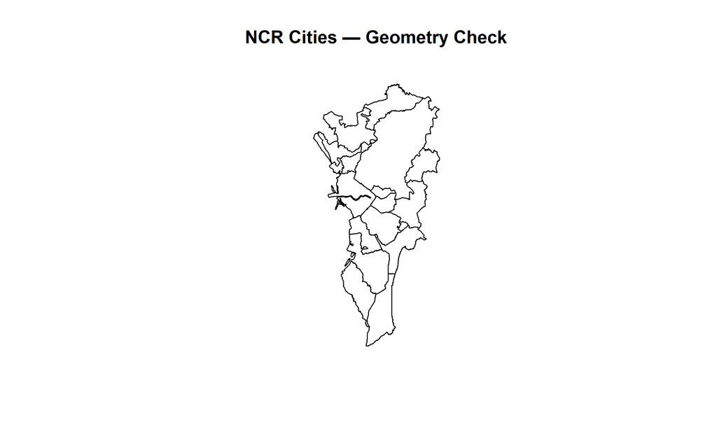

```r
# City centroids for all label layers
ncr_centroids <- ncr_map %>%
  st_centroid() %>%
  mutate(
    lon = st_coordinates(.)[, 1],
    lat = st_coordinates(.)[, 2]
  )

plot(st_geometry(ncr_map), main = "NCR Cities — Geometry Check")
```

**Tip**

**Key concept: the join key**  
The `left_join(by = "city")` links rows in the shapefile to rows in our dataset using the city name as the common key. In production, it is better to use a numeric code (PSGC) to avoid string-matching errors — but city names work fine for our 17-unit NCR dataset.

## 3 · Choropleth Maps

A **choropleth map** shades geographic units by a variable’s value. We use `ggplot2` for publication-quality static maps.

### 3.1 Mean rent value

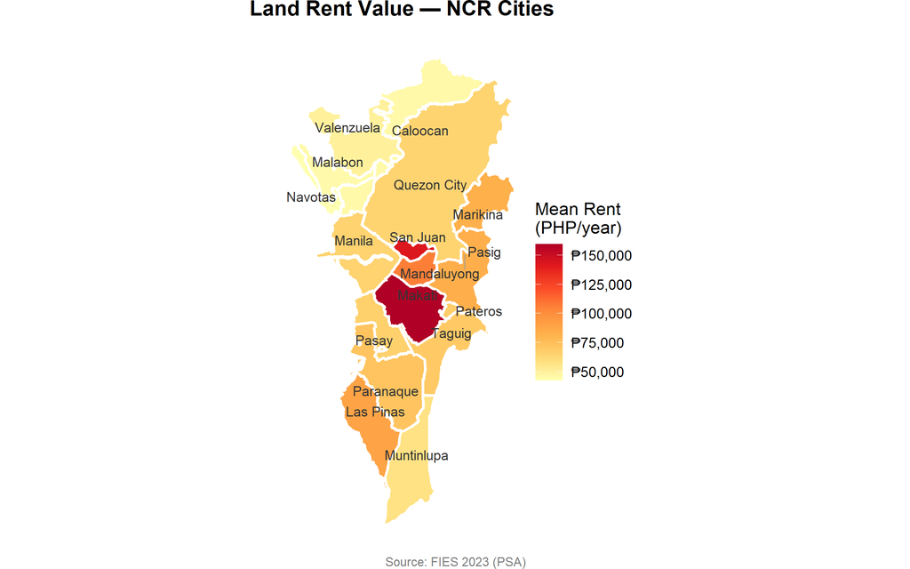

Mean household rent value (PHP/year) by NCR city, FIES 2023

```r
ggplot(ncr_map) +
  geom_sf(aes(fill = mean_rentval), color = "white", linewidth = 0.8) +
  geom_text_repel(
    data          = ncr_centroids,
    aes(x = lon, y = lat, label = city),
    size          = 3,
    color         = "grey20",
    max.overlaps  = 20,
    segment.size  = 0.3,
    segment.color = "grey60"
  ) +
  scale_fill_distiller(
    palette   = "YlOrRd",
    direction = 1,
    labels    = comma_format(prefix = "₱"),
    name      = "Mean Rent\n(PHP/year)"
  ) +
  labs(
    title   = "Land Rent Value — NCR Cities",
    caption = "Source: FIES 2023 (PSA)"
  ) +
  theme_void(base_size = 11) +
  theme(
    plot.title      = element_text(face = "bold", hjust = 0.5,
                                   margin = margin(b = 8)),
    plot.caption    = element_text(color = "grey50", size = 8),
    legend.position = "right"
  )
```

### 3.2 College graduation rate

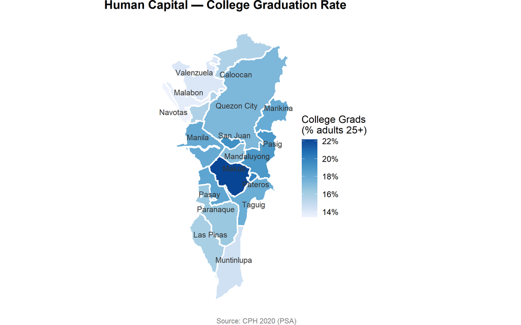

Share of adults 25+ with college degree (%), CPH 2020

```r
ggplot(ncr_map) +
  geom_sf(aes(fill = pct_college_grad), color = "white", linewidth = 0.8) +
  geom_text_repel(
    data = ncr_centroids,
    aes(x = lon, y = lat, label = city),
    size = 3, color = "grey20",
    max.overlaps = 20,
    segment.size = 0.3, segment.color = "grey60"
  ) +
  scale_fill_distiller(
    palette = "Blues", direction = 1,
    labels  = function(x) paste0(round(x, 1), "%"),
    name    = "College Grads\n(% adults 25+)"
  ) +
  labs(
    title   = "Human Capital — College Graduation Rate",
    caption = "Source: CPH 2020 (PSA)"
  ) +
  theme_void(base_size = 11) +
  theme(
    plot.title      = element_text(face = "bold", hjust = 0.5,
                                   margin = margin(b = 8)),
    plot.caption    = element_text(color = "grey50", size = 8),
    legend.position = "right"
  )
```

### 3.3 Side-by-side comparison

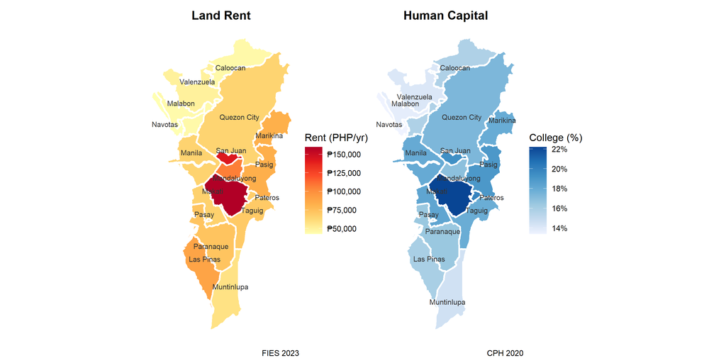

Rent value vs college graduation rate — NCR cities

```r
p_rent <- ggplot(ncr_map) +
  geom_sf(aes(fill = mean_rentval), color = "white", linewidth = 0.8) +
  geom_text_repel(
    data = ncr_centroids,
    aes(x = lon, y = lat, label = city),
    size = 2.5, color = "grey20", max.overlaps = 20,
    segment.size = 0.3, segment.color = "grey60"
  ) +
  scale_fill_distiller(palette = "YlOrRd", direction = 1,
                       labels = comma_format(prefix = "₱"),
                       name = "Rent (PHP/yr)") +
  labs(title = "Land Rent", caption = "FIES 2023") +
  theme_void(base_size = 10) +
  theme(plot.title = element_text(face = "bold", hjust = 0.5))

p_college <- ggplot(ncr_map) +
  geom_sf(aes(fill = pct_college_grad), color = "white", linewidth = 0.8) +
  geom_text_repel(
    data = ncr_centroids,
    aes(x = lon, y = lat, label = city),
    size = 2.5, color = "grey20", max.overlaps = 20,
    segment.size = 0.3, segment.color = "grey60"
  ) +
  scale_fill_distiller(palette = "Blues", direction = 1,
                       labels = function(x) paste0(round(x, 1), "%"),
                       name = "College (%)") +
  labs(title = "Human Capital", caption = "CPH 2020") +
  theme_void(base_size = 10) +
  theme(plot.title = element_text(face = "bold", hjust = 0.5))

p_rent + p_college
```

**Note**

**What do you notice?**  
The two maps should show a broadly similar spatial pattern — cities with higher rent tend to have higher college graduation rates. This is the **agglomeration premium**: skilled workers cluster where productivity (and land rent) is highest.

## 4 · The Land Rent Gradient

The **Alonso–Muth–Mills (AMM) model** predicts that land rent declines with distance from the CBD as households trade off commuting costs against housing costs. Let’s test this with our NCR data.

### 4.1 Scatter plot: rent vs distance

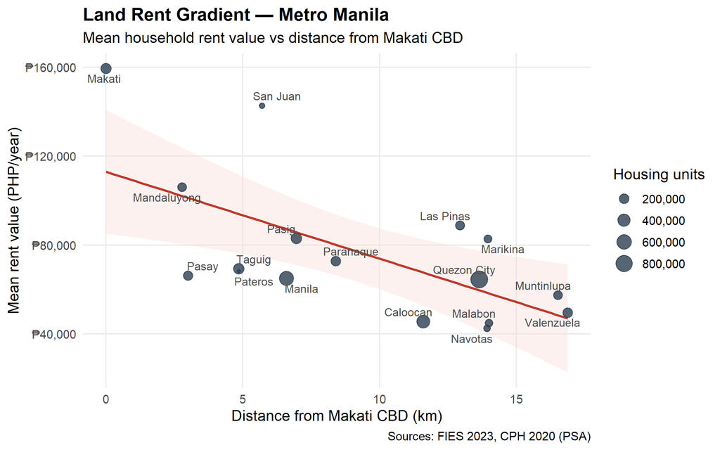

Land rent gradient — NCR cities, 2023

```r
ggplot(ncr_city, aes(x = dist_cbd_km, y = mean_rentval)) +
  geom_smooth(method = "lm", se = TRUE,
              colour = "#c0392b", fill = "#fadbd8", linewidth = 1) +
  geom_point(aes(size = n_hh), colour = "#2c3e50", alpha = 0.8) +
  geom_text_repel(aes(label = city), size = 3.2, colour = "grey30",
                  max.overlaps = 20) +
  scale_y_continuous(labels = comma_format(prefix = "₱")) +
  scale_x_continuous(breaks = seq(0, 20, 5)) +
  scale_size_continuous(labels = comma, name = "Housing units") +
  labs(
    title    = "Land Rent Gradient — Metro Manila",
    subtitle = "Mean household rent value vs distance from Makati CBD",
    x        = "Distance from Makati CBD (km)",
    y        = "Mean rent value (PHP/year)",
    caption  = "Sources: FIES 2023, CPH 2020 (PSA)"
  ) +
  theme_minimal(base_size = 12) +
  theme(
    plot.title    = element_text(face = "bold"),
    panel.grid.minor = element_blank()
  )
```

### 4.2 Fit the gradient model

```r
# Simple log-linear rent gradient model
# ln(rent) = α + β × distance + ε
# β < 0 confirms the AMM prediction

model <- lm(log(mean_rentval) ~ dist_cbd_km, data = ncr_city)
summary(model)
```

```
Call:
lm(formula = log(mean_rentval) ~ dist_cbd_km, data = ncr_city)

Residuals:
     Min       1Q   Median       3Q      Max
-0.36798 -0.24709 -0.01114  0.11692  0.52526

Coefficients:
            Estimate Std. Error t value Pr(>|t|)
(Intercept) 11.60758    0.14712  78.898  < 2e-16 ***
dist_cbd_km -0.04643    0.01395  -3.327  0.00459 **
---
Signif. codes:  0 '***' 0.001 '**' 0.01 '*' 0.05 '.' 0.1 ' ' 1

Residual standard error: 0.295 on 15 degrees of freedom
Multiple R-squared:  0.4247,    Adjusted R-squared:  0.3863
F-statistic: 11.07 on 1 and 15 DF,  p-value: 0.004594
```

**Important**

**Interpreting β**  
The coefficient on `dist_cbd_km` tells us: for each additional kilometre from Makati CBD, rent changes by approximately `exp(β) - 1` × 100 percent. A negative β confirms the AMM gradient.

### 4.3 Rent-to-income ratio gradient

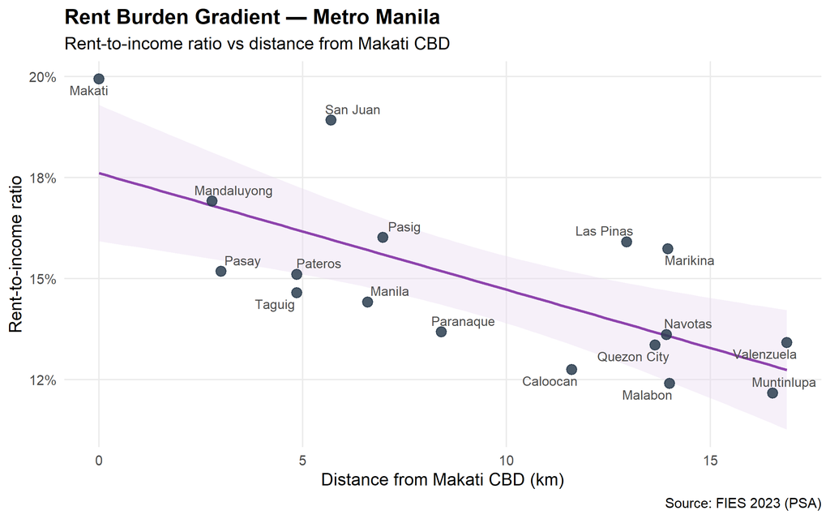

Rent burden (rent-to-income ratio) vs distance from CBD

```r
ggplot(ncr_city, aes(x = dist_cbd_km, y = rent_inc_ratio)) +
  geom_smooth(method = "lm", se = TRUE,
              colour = "#8e44ad", fill = "#e8daef", linewidth = 1) +
  geom_point(colour = "#2c3e50", size = 3, alpha = 0.85) +
  geom_text_repel(aes(label = city), size = 3.2, colour = "grey30",
                  max.overlaps = 20) +
  scale_y_continuous(labels = percent_format(accuracy = 1)) +
  scale_x_continuous(breaks = seq(0, 20, 5)) +
  labs(
    title    = "Rent Burden Gradient — Metro Manila",
    subtitle = "Rent-to-income ratio vs distance from Makati CBD",
    x        = "Distance from Makati CBD (km)",
    y        = "Rent-to-income ratio",
    caption  = "Source: FIES 2023 (PSA)"
  ) +
  theme_minimal(base_size = 12) +
  theme(
    plot.title       = element_text(face = "bold"),
    panel.grid.minor = element_blank()
  )
```

## 5 · Human Capital and Urban Productivity

### 5.1 College graduation vs rent

The **human capital theory of cities** (Glaeser et al.) argues that skilled workers are more productive in dense, high-rent areas because of knowledge spillovers and thick labour markets.

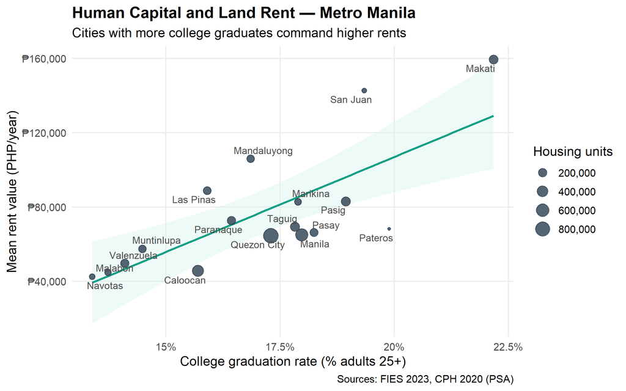

College graduation rate vs mean rent value — NCR cities

```r
ggplot(ncr_city, aes(x = pct_college_grad, y = mean_rentval)) +
  geom_smooth(method = "lm", se = TRUE,
              colour = "#16a085", fill = "#d1f2eb", linewidth = 1) +
  geom_point(aes(size = n_hh), colour = "#2c3e50", alpha = 0.8) +
  geom_text_repel(aes(label = city), size = 3.2, colour = "grey30",
                  max.overlaps = 20) +
  scale_y_continuous(labels = comma_format(prefix = "₱")) +
  scale_x_continuous(labels = function(x) paste0(x, "%")) +
  scale_size_continuous(labels = comma, name = "Housing units") +
  labs(
    title    = "Human Capital and Land Rent — Metro Manila",
    subtitle = "Cities with more college graduates command higher rents",
    x        = "College graduation rate (% adults 25+)",
    y        = "Mean rent value (PHP/year)",
    caption  = "Sources: FIES 2023, CPH 2020 (PSA)"
  ) +
  theme_minimal(base_size = 12) +
  theme(
    plot.title       = element_text(face = "bold"),
    panel.grid.minor = element_blank()
  )
```

### 5.2 Education expenditure vs income

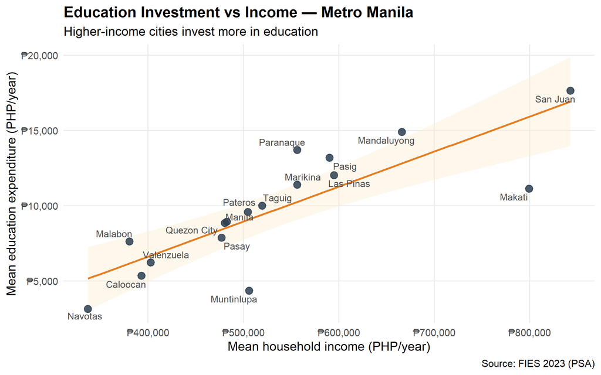

Education expenditure vs household income — NCR cities

```r
ggplot(ncr_city, aes(x = mean_inc, y = mean_educ_exp)) +
  geom_smooth(method = "lm", se = TRUE,
              colour = "#e67e22", fill = "#fdebd0", linewidth = 1) +
  geom_point(colour = "#2c3e50", size = 3, alpha = 0.85) +
  geom_text_repel(aes(label = city), size = 3.2, colour = "grey30",
                  max.overlaps = 20) +
  scale_x_continuous(labels = comma_format(prefix = "₱")) +
  scale_y_continuous(labels = comma_format(prefix = "₱")) +
  labs(
    title    = "Education Investment vs Income — Metro Manila",
    subtitle = "Higher-income cities invest more in education",
    x        = "Mean household income (PHP/year)",
    y        = "Mean education expenditure (PHP/year)",
    caption  = "Source: FIES 2023 (PSA)"
  ) +
  theme_minimal(base_size = 12) +
  theme(
    plot.title       = element_text(face = "bold"),
    panel.grid.minor = element_blank()
  )
```

### 5.3 Four-panel productivity dashboard

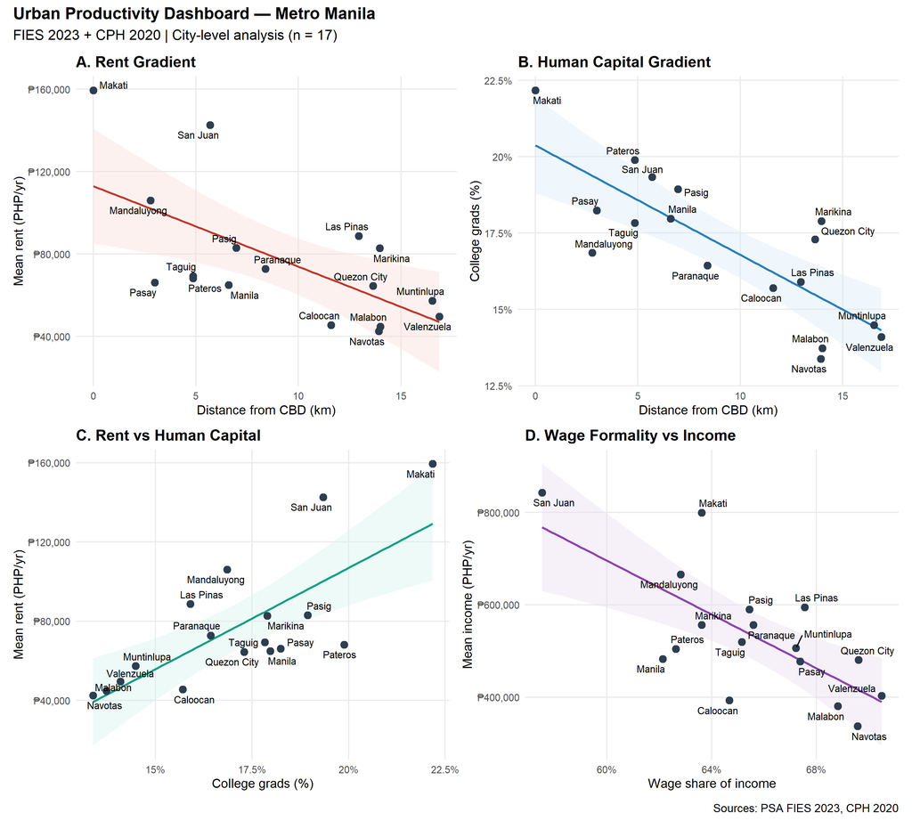

Urban productivity indicators — NCR cities

```r
p1 <- ggplot(ncr_city, aes(dist_cbd_km, mean_rentval)) +
  geom_smooth(method = "lm", se = TRUE, colour = "#c0392b",
              fill = "#fadbd8", linewidth = 0.8) +
  geom_point(colour = "#2c3e50", size = 2.5) +
  geom_text_repel(aes(label = city), size = 2.8, max.overlaps = 15) +
  scale_y_continuous(labels = comma_format(prefix = "₱")) +
  labs(title = "A. Rent Gradient",
       x = "Distance from CBD (km)", y = "Mean rent (PHP/yr)") +
  theme_minimal(base_size = 10) +
  theme(plot.title = element_text(face = "bold"),
        panel.grid.minor = element_blank())

p2 <- ggplot(ncr_city, aes(dist_cbd_km, pct_college_grad)) +
  geom_smooth(method = "lm", se = TRUE, colour = "#2980b9",
              fill = "#d6eaf8", linewidth = 0.8) +
  geom_point(colour = "#2c3e50", size = 2.5) +
  geom_text_repel(aes(label = city), size = 2.8, max.overlaps = 15) +
  scale_y_continuous(labels = function(x) paste0(x, "%")) +
  labs(title = "B. Human Capital Gradient",
       x = "Distance from CBD (km)", y = "College grads (%)") +
  theme_minimal(base_size = 10) +
  theme(plot.title = element_text(face = "bold"),
        panel.grid.minor = element_blank())

p3 <- ggplot(ncr_city, aes(pct_college_grad, mean_rentval)) +
  geom_smooth(method = "lm", se = TRUE, colour = "#16a085",
              fill = "#d1f2eb", linewidth = 0.8) +
  geom_point(colour = "#2c3e50", size = 2.5) +
  geom_text_repel(aes(label = city), size = 2.8, max.overlaps = 15) +
  scale_y_continuous(labels = comma_format(prefix = "₱")) +
  scale_x_continuous(labels = function(x) paste0(x, "%")) +
  labs(title = "C. Rent vs Human Capital",
       x = "College grads (%)", y = "Mean rent (PHP/yr)") +
  theme_minimal(base_size = 10) +
  theme(plot.title = element_text(face = "bold"),
        panel.grid.minor = element_blank())

p4 <- ggplot(ncr_city, aes(wage_inc_share, mean_inc)) +
  geom_smooth(method = "lm", se = TRUE, colour = "#8e44ad",
              fill = "#e8daef", linewidth = 0.8) +
  geom_point(colour = "#2c3e50", size = 2.5) +
  geom_text_repel(aes(label = city), size = 2.8, max.overlaps = 15) +
  scale_y_continuous(labels = comma_format(prefix = "₱")) +
  scale_x_continuous(labels = percent_format(accuracy = 1)) +
  labs(title = "D. Wage Formality vs Income",
       x = "Wage share of income", y = "Mean income (PHP/yr)") +
  theme_minimal(base_size = 10) +
  theme(plot.title = element_text(face = "bold"),
        panel.grid.minor = element_blank())

(p1 + p2) / (p3 + p4) +
  plot_annotation(
    title   = "Urban Productivity Dashboard — Metro Manila",
    subtitle = "FIES 2023 + CPH 2020 | City-level analysis (n = 17)",
    caption  = "Sources: PSA FIES 2023, CPH 2020",
    theme    = theme(plot.title = element_text(face = "bold", size = 13))
  )
```

## 6 · Exercises

**Tip**

**Exercise 1 — Map a new variable**  
Produce a choropleth map of `pct_makeshift_wall` (informality proxy). Which cities have the highest rates? Does this align with what you know about NCR urban geography?

**Tip**

**Exercise 2 — Test a different gradient**  
Fit the log-linear gradient model using `pct_college_grad` as the dependent variable instead of `mean_rentval`. Is the human capital gradient steeper or flatter than the rent gradient?

**Tip**

**Exercise 3 — OFW and rent**  
Plot `pct_ofw` (overseas workers) against `dist_cbd_km`. Do peripheral cities have more OFWs? What might this tell us about the relationship between local labour market opportunities and international migration?